# VAR(p): Estimación, diagnóstico y pronóstico

Javier López

2 de mayo de 2020

## **Estimación**

Tenemos que el modelo **VAR(p)** tiene la siguiente estructura:
$$\mathbf{Y_t} = \phi_0 + \phi_1 \mathbf{Y_{t-1}} + ... + \phi_p \mathbf{Y_{t-p}} + a_t \;\;\ con \;\;\ t= p+1,..., n$$
De forma matricial, podemos ver el modelo de la siguiente manera:
$$\mathbf{y_t}^´= \mathbf{x_t}^´ \mathbf{\beta} + \mathbf{a_t}^´ \;\;\ donde \;\;\ \mathbf{x_t}=(1, Y_{t-1}^´,...,Y_{t-p}^´), \;\ \beta=(\phi_0, \phi_1, ...,\phi_p )$$
Así, tenemos que:
$$\mathbf{Y} = \mathbf{X}\mathbf{B} + \mathbf{A}$$
luego la suma de cuadrados a maximizar está dada por:
$$S(\beta)=tr[(\mathbf{Y} - \mathbf{X}\mathbf{B})\Sigma_a^{-1}(\mathbf{Y} - \mathbf{X}\mathbf{B})^´]$$
Derivando respecto a $\mathbf{B}$ tenemos que:
$$\hat{\beta}=(X^´X)(X^´\mathbf{Y})=\left[\sum_{t=p+1}^{n}x_tx_t^´\right]^{-1}\sum_{t=p+1}^{n}x_tY_t^´$$

### **Máxima Verosimilitud**

Asumiendo que $\mathbf{a_t} \sim NM(\mathbf{0},\Sigma_a)$, tenemos que:
$$\begin{align*}
L(\mathbf{Y}|\beta,\Sigma_a) &= \prod_{t=p+1}^nP(Y|Y_{t+1},\beta,\Sigma_a)\\
&=\prod_{t=p+1}^nP(\mathbf{a_t}|\beta,\Sigma_a)\\
&=\prod_{t=p+1}^n \dfrac{1}{2\pi^{\frac{k}{2}}|\Sigma_a|^\frac{1}{2}} exp \left[-\dfrac{1}{2}\mathbf{a_t}^´\Sigma_a\mathbf{a_t} \right] \\
&\propto |\Sigma_a|^{-\frac{\pi-p}{2}} exp \left[-\dfrac{1}{2}\sum_{t=p+1}^n tr(\mathbf{a_t}^´\Sigma_a\mathbf{a_t}) \right]
\end{align*}$$
luego:
$$\begin{align*}
l(\beta,\Sigma_a) &= log(L(\mathbf{Y}|\beta,\Sigma_a))\\
&=c-\dfrac{n-p}{2}log(|\Sigma_a|)-\dfrac{1}{2}S(\beta)
\end{align*}$$
Así tenemos:
$$\hat{\beta}=\Sigma_a^{-1}\otimes X^´X$$

### Ejemplo estimación MV: datos PIB UK, Canada, USA

```r
#################################################################
#################################################################
#####   Programa Clase 6 - Series de Tiempo                  ####
#####   Fecha de creación: 20200430                          ####
#####   Fecha de última edición: 20200430                    ####
#####   Autor: Edgar Javier López Moreno                     ####
#####   E-mail: edgar.lopez@libertadores.edu.co              ####
#################################################################
#################################################################

rm(list = ls())

#################################################################
#####                   Librerias utilizadas                #####
#################################################################

library(TSA)
library(MTS)
library(mvtnorm)
library(readxl)
library(data.table)
library(dplyr)
library(ggplot2)

#################################################################
#####                   Sistema de carpetas                 #####
#################################################################

inpath  <- "D:/PERSONAL/6. EDUCACIÓN/1-LIBERTADORES/1-SERIES DE TIEMPO/inpath/"
outpath <- "D:/PERSONAL/6. EDUCACIÓN/1-LIBERTADORES/1-SERIES DE TIEMPO/outpath/"

#################################################################
#####                   Carga de información                #####
#################################################################

GDP_UKCAUS <- read_excel(paste(inpath,"GDP UK CA US.xlsx", sep = ""))

print(head(GDP_UKCAUS))
```

```
## # A tibble: 6 x 5
##    year   mon     uk     ca      us
##   <dbl> <dbl>  <dbl>  <dbl>   <dbl>
## 1  1980     1 172436 624794 5908500
## 2  1980     4 169359 623433 5787400
## 3  1980     7 169038 623215 5776600
## 4  1980    10 167180 630215 5883500
## 5  1981     1 166052 645957 6005700
## 6  1981     4 166393 651954 5957800
```

Descriptiva de los PIB de UK, Canadá y USA:

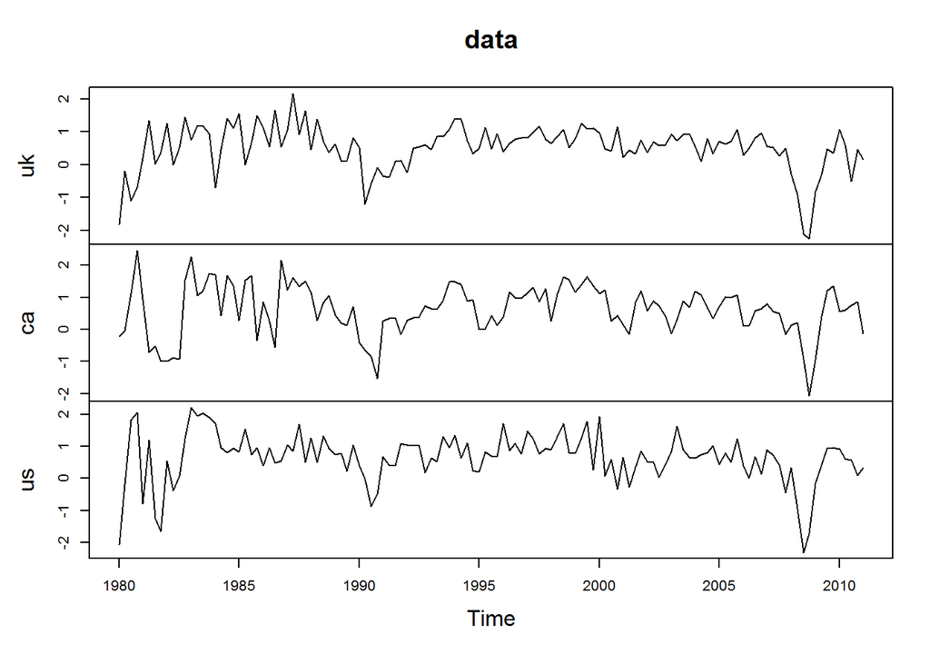

```r
#################################################################
#####                   Ejecución Programa                  #####
#################################################################

gdp<- log(GDP_UKCAUS[,3:5])
uk <- ts(diff(gdp$uk), start = c(1980, 1), frequency = 4)
ca <- ts(diff(gdp$ca), start = c(1980, 1), frequency = 4)
us <- ts(diff(gdp$us), start = c(1980, 1), frequency = 4)
gdp.ret <- cbind(uk,ca,us)*100
MTSplot(gdp.ret)
```

```r
VARorder(gdp.ret)
```

```
## selected order: aic =  2
## selected order: bic =  1
## selected order: hq =  1
## Summary table:
##        p     AIC     BIC      HQ     M(p) p-value
##  [1,]  0 -3.3250 -3.3250 -3.3250   0.0000  0.0000
##  [2,]  1 -4.2520 -4.0484 -4.1693 115.1329  0.0000
##  [3,]  2 -4.3333 -3.9260 -4.1678  23.5389  0.0051
##  [4,]  3 -4.2926 -3.6817 -4.0444  10.4864  0.3126
##  [5,]  4 -4.2661 -3.4516 -3.9352  11.5767  0.2382
##  [6,]  5 -4.1508 -3.1326 -3.7372   2.7406  0.9737
##  [7,]  6 -4.0801 -2.8583 -3.5838   6.7822  0.6598
##  [8,]  7 -3.9869 -2.5615 -3.4079   4.5469  0.8719
##  [9,]  8 -4.1260 -2.4969 -3.4642  24.4833  0.0036
## [10,]  9 -4.0586 -2.2259 -3.3141   6.4007  0.6992
## [11,] 10 -3.9683 -1.9320 -3.1411   4.3226  0.8889
## [12,] 11 -3.9726 -1.7326 -3.0626  11.4922  0.2435
## [13,] 12 -3.9872 -1.5436 -2.9945  11.8168  0.2238
## [14,] 13 -4.0408 -1.3935 -2.9654  14.1266  0.1179
```

```r
criterios <- data.frame(cbind(round(0:13,0),VARorder(gdp.ret)$aic,
                              VARorder(gdp.ret)$bic,
                              VARorder(gdp.ret)$hq))
names(criterios) <- c('p', 'AIC', 'BIC', 'HQ')

plot.crite <- data.frame(rbind(cbind(round(0:13,0), 'AIC', VARorder(gdp.ret)$aic),
                               cbind(round(0:13,0), 'BIC', VARorder(gdp.ret)$bic),
                               cbind(round(0:13,0), 'HQ', VARorder(gdp.ret)$hq)))
names(plot.crite) <- c('p', 'Criterio', 'Valores')
plot.crite$p       <- as.numeric(as.character(plot.crite$p))
plot.crite$Valores <- as.numeric(as.character(plot.crite$Valores))
```

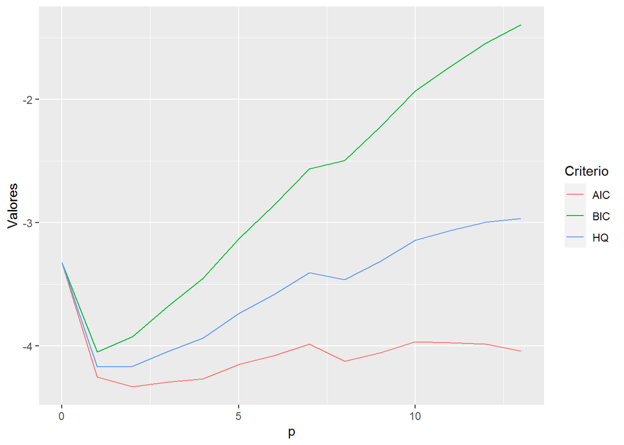

```r
ggplot(plot.crite, aes(x = p,y = Valores, group = Criterio)) +
  geom_line(aes(color = Criterio))
```

Así, tenemos que la estimación por máxima verosimilitud utilizando la función *VAR* es igual a:

```r
modelo <- VAR(gdp.ret, 2)
```

```
## Constant term:
## Estimates:  0.1258163 0.1231581 0.2895581
## Std.Error:  0.07266338 0.07382941 0.0816888
## AR coefficient matrix
## AR( 1 )-matrix
##       [,1]  [,2]   [,3]
## [1,] 0.393 0.103 0.0521
## [2,] 0.351 0.338 0.4691
## [3,] 0.491 0.240 0.2356
## standard error
##        [,1]   [,2]   [,3]
## [1,] 0.0934 0.0984 0.0911
## [2,] 0.0949 0.1000 0.0926
## [3,] 0.1050 0.1106 0.1024
## AR( 2 )-matrix
##         [,1]   [,2]     [,3]
## [1,]  0.0566  0.106  0.01889
## [2,] -0.1914 -0.175 -0.00868
## [3,] -0.3120 -0.131  0.08531
## standard error
##        [,1]   [,2]   [,3]
## [1,] 0.0924 0.0876 0.0938
## [2,] 0.0939 0.0890 0.0953
## [3,] 0.1038 0.0984 0.1055
##
## Residuals cov-mtx:
##            [,1]       [,2]       [,3]
## [1,] 0.28244420 0.02654091 0.07435286
## [2,] 0.02654091 0.29158166 0.13948786
## [3,] 0.07435286 0.13948786 0.35696571
##
## det(SSE) =  0.02258974
## AIC =  -3.502259
## BIC =  -3.094982
## HQ  =  -3.336804
```

Así tenemos que:
$$\begin{bmatrix}
Y_{1t}\\
Y_{2t}\\
Y_{3t}
\end{bmatrix} =
\begin{bmatrix}
0.13\\
0.12\\
0.29
\end{bmatrix} +
\begin{bmatrix}
0.39 & 0.10 & 0.05 \\
0.35 & 0.34 & 0.47 \\
0.49 & 0.24 & 0.24
\end{bmatrix}
\begin{bmatrix}
Y_{1,t-1}\\
Y_{2,t-1}\\
Y_{3,t-1}
\end{bmatrix} +
\begin{bmatrix}
0.06 & 0.11 & 0.02 \\
-0.19 & -0.18 & -0.01 \\
-0.31 & -0.13 & 0.09
\end{bmatrix}
\begin{bmatrix}
Y_{1,t-2}\\
Y_{2,t-2}\\
Y_{3,t-2}
\end{bmatrix} +
\begin{bmatrix}
a_{1t}\\
a_{2t}\\
a_{3t}
\end{bmatrix}$$
y la estimación de la matriz de varianzas y covarianzas:
$$\hat{\Sigma}_a= \begin{bmatrix}
0.28 & 0.03 & 0.07 \\
0.03 & 0.29 & 0.14 \\
0.07 & 0.14 & 0.36
\end{bmatrix}$$

## **Diagnóstico del Modelo**

Al igual que en el caso univariado, el interés está en revisar la correlación de los residuales, luego planteamos la siguiente hipótesis:
$$\begin{align*}
H_0 &: R_1 = R_2 = ... R_m = \mathbf{0}\\
H_a &: R_j \neq \mathbf{0} \;\ para \;\ 1 \leq j \leq m
\end{align*}$$
donde $R_l$ es la matriz de correlación cruzada del rezago $l$.

### Estadística de Portmanteau

$$Q_k(m)=n^2 \sum_{l=1}^m \dfrac{1}{n-l}tr\left( \hat{C}_l^´ \hat{C}_0^{-1} \hat{C}_l \hat{C}_0^{-1} \right)$$

```r
### Residuales
names(modelo)
```

```
##  [1] "data"      "cnst"      "order"     "coef"      "aic"
##  [6] "bic"       "hq"        "residuals" "secoef"    "Sigma"
## [11] "Phi"       "Ph0"       "fixed"
```

```r
resi <- modelo$residuals
mq(resi,adj=18)
```

```
## Ljung-Box Statistics:
##           m       Q(m)     df    p-value
##  [1,]   1.000     0.816  -9.000     1.00
##  [2,]   2.000     3.978   0.000     1.00
##  [3,]   3.000    16.665   9.000     0.05
##  [4,]   4.000    35.122  18.000     0.01
##  [5,]   5.000    38.189  27.000     0.07
##  [6,]   6.000    41.239  36.000     0.25
##  [7,]   7.000    47.621  45.000     0.37
##  [8,]   8.000    61.677  54.000     0.22
##  [9,]   9.000    67.366  63.000     0.33
## [10,]  10.000    76.930  72.000     0.32
## [11,]  11.000    81.567  81.000     0.46
## [12,]  12.000    93.112  90.000     0.39
## [13,]  13.000   105.327  99.000     0.31
## [14,]  14.000   116.279 108.000     0.28
## [15,]  15.000   128.974 117.000     0.21
## [16,]  16.000   134.704 126.000     0.28
## [17,]  17.000   138.552 135.000     0.40
## [18,]  18.000   146.256 144.000     0.43
## [19,]  19.000   162.418 153.000     0.29
## [20,]  20.000   171.948 162.000     0.28
## [21,]  21.000   174.913 171.000     0.40
## [22,]  22.000   182.056 180.000     0.44
## [23,]  23.000   190.276 189.000     0.46
## [24,]  24.000   202.141 198.000     0.41
```

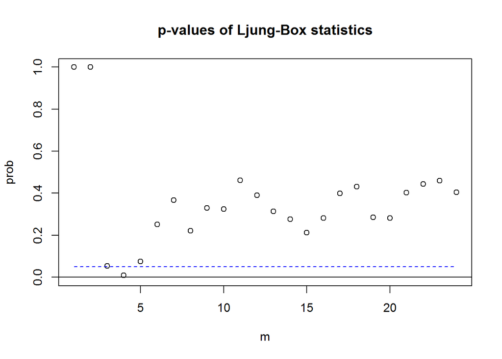

Para $m=4$ el p-valor está por debajo de $0.05$ lo que indica rechazar $H_0$. Es decir que hay suficiente evidencia estadística para decir que hay correlación en los residuos.

### Testeando Parámetros Cero

Haciendo uso de la función *refVAR* se realiza una refinación del modelo, donde nos permitirá ver cuales son los parámetros significativos:

```r
### Simplificación del modelo
modelo.2 <- refVAR(modelo, thres = 1.96) # Model refinement.
```

```
## Constant term:
## Estimates:  0.1628247 0 0.2827525
## Std.Error:  0.06814101 0 0.07972864
## AR coefficient matrix
## AR( 1 )-matrix
##       [,1]  [,2]  [,3]
## [1,] 0.467 0.207 0.000
## [2,] 0.334 0.270 0.496
## [3,] 0.468 0.225 0.232
## standard error
##        [,1]   [,2]   [,3]
## [1,] 0.0790 0.0686 0.0000
## [2,] 0.0921 0.0875 0.0913
## [3,] 0.1027 0.0963 0.1023
## AR( 2 )-matrix
##        [,1] [,2] [,3]
## [1,]  0.000    0    0
## [2,] -0.197    0    0
## [3,] -0.301    0    0
## standard error
##        [,1] [,2] [,3]
## [1,] 0.0000    0    0
## [2,] 0.0921    0    0
## [3,] 0.1008    0    0
##
## Residuals cov-mtx:
##            [,1]       [,2]       [,3]
## [1,] 0.29003669 0.01803456 0.07055856
## [2,] 0.01803456 0.30802503 0.14598345
## [3,] 0.07055856 0.14598345 0.36268779
##
## det(SSE) =  0.02494104
## AIC =  -3.531241
## BIC =  -3.304976
## HQ  =  -3.439321
```

Así tenemos que:
$$\mathbf{Y_t} =
\begin{bmatrix}
0.16\\
-\\
0.28
\end{bmatrix} +
\begin{bmatrix}
0.47 & 0.21 & - \\
0.33 & 0.27 & 0.50 \\
0.47 & 0.23 & 0.23
\end{bmatrix}
\mathbf{Y_{t-1}} +
\begin{bmatrix}
- & - & - \\
-0.20 & - & - \\
-0.30 & - & -
\end{bmatrix}
\mathbf{Y_{t-2}}+
\mathbf{a_t}$$
y la estimación de la matriz de varianzas y covarianzas:
$$\hat{\Sigma}_a= \begin{bmatrix}
0.29 & 0.02 & 0.07 \\
0.02 & 0.31 & 0.15 \\
0.07 & 0.15 & 0.36
\end{bmatrix}$$
Ahora todas las estimaciones son significativas al nivel $5\%$.

Chequeando el modelo con la función *MTSdiag* tenemos que:

```r
MTSdiag(modelo.2, adj=12)
```

```
## [1] "Covariance matrix:"
##        uk     ca     us
## uk 0.2924 0.0182 0.0711
## ca 0.0182 0.3084 0.1472
## us 0.0711 0.1472 0.3657
## CCM at lag:  0
##        [,1]   [,2]  [,3]
## [1,] 1.0000 0.0605 0.218
## [2,] 0.0605 1.0000 0.438
## [3,] 0.2175 0.4382 1.000
## Simplified matrix:
## CCM at lag:  1
## . . .
## . . .
## . . .
## CCM at lag:  2
## . . .
## . . .
## . . .
## CCM at lag:  3
## . . .
## . . .
## . . .
## CCM at lag:  4
## . . -
## . . .
## . . .
## CCM at lag:  5
## . . .
## . . .
## . . .
## CCM at lag:  6
## . . .
## . . .
## . . .
## CCM at lag:  7
## . . .
## . . .
## . . .
## CCM at lag:  8
```

[output cut: 52 more lines]

```
## . . .
## . . .
## . . .
## CCM at lag:  22
## . . .
## . . .
## . . .
## CCM at lag:  23
## . . .
## . . .
## . . .
## CCM at lag:  24
## . . .
## . . .
## . . .
```

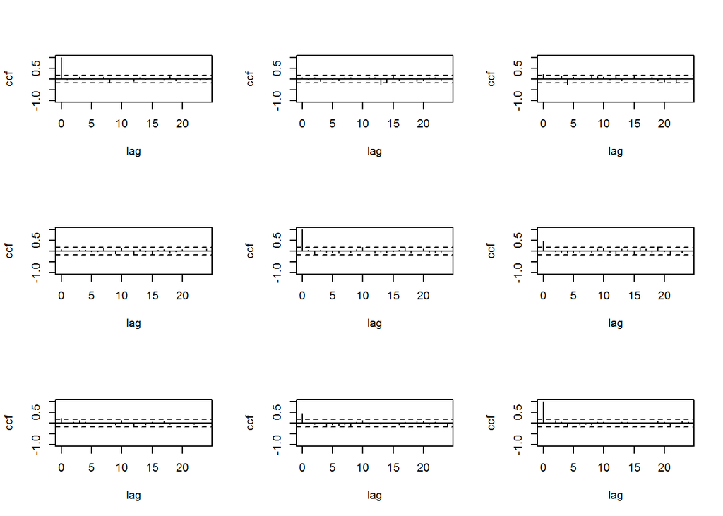

```
## Hit Enter for p-value plot of individual ccm:
```

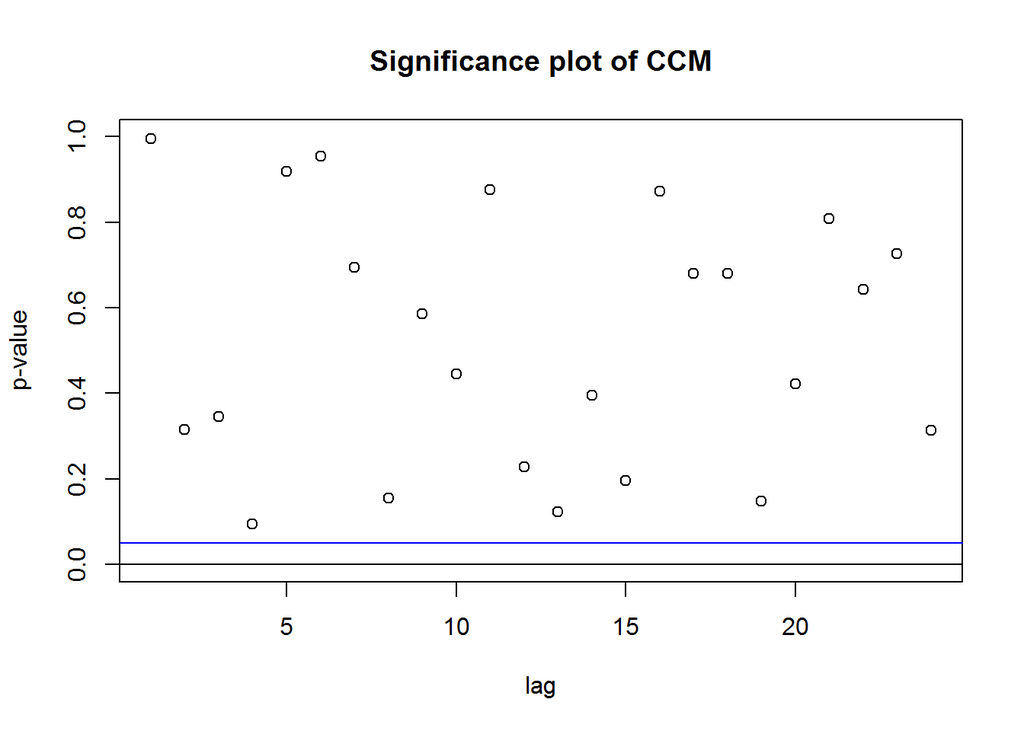

```
## Hit Enter to compute MQ-statistics:
##
## Ljung-Box Statistics:
##          m       Q(m)     df    p-value
##  [1,]   1.00      1.78   -3.00     1.00
##  [2,]   2.00     12.41    6.00     1.00
##  [3,]   3.00     22.60   15.00     0.09
##  [4,]   4.00     37.71   24.00     0.04
##  [5,]   5.00     41.65   33.00     0.14
##  [6,]   6.00     44.95   42.00     0.35
##  [7,]   7.00     51.50   51.00     0.45
##  [8,]   8.00     64.87   60.00     0.31
##  [9,]   9.00     72.50   69.00     0.36
## [10,]  10.00     81.58   78.00     0.37
## [11,]  11.00     86.12   87.00     0.51
## [12,]  12.00     98.08   96.00     0.42
## [13,]  13.00    112.31  105.00     0.30
## [14,]  14.00    121.89  114.00     0.29
## [15,]  15.00    134.58  123.00     0.22
## [16,]  16.00    139.16  132.00     0.32
## [17,]  17.00    145.85  141.00     0.37
## [18,]  18.00    152.56  150.00     0.43
## [19,]  19.00    165.91  159.00     0.34
## [20,]  20.00    175.22  168.00     0.34
## [21,]  21.00    180.56  177.00     0.41
## [22,]  22.00    187.40  186.00     0.46
## [23,]  23.00    193.78  195.00     0.51
## [24,]  24.00    204.65  204.00     0.47
```

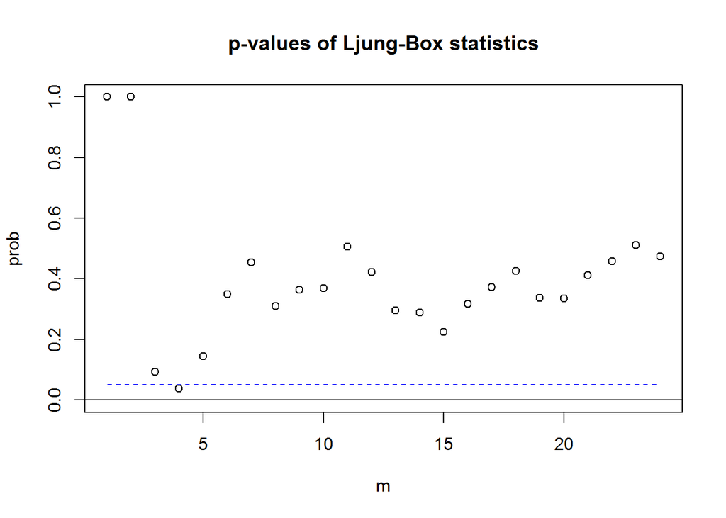

```
## Hit Enter to obtain residual plots:
```

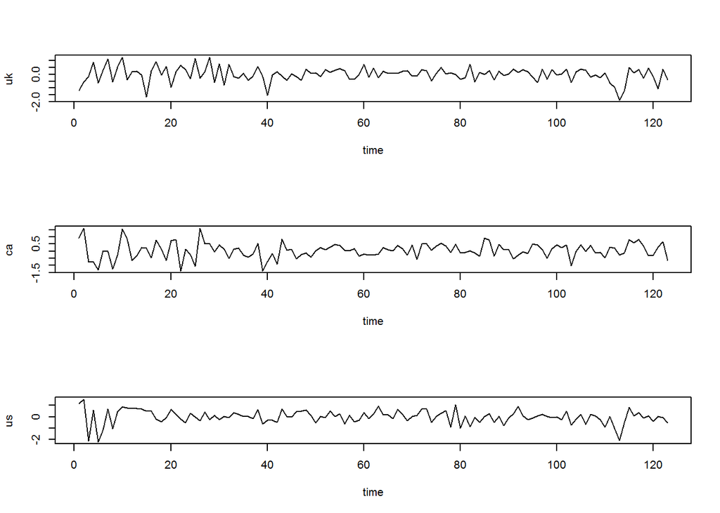

$$\begin{align*}
UK: \mathbf{Y_{1t}} &= 0.16 + 0.47\mathbf{Y_{1,t-1}} + 0.21\mathbf{Y_{2,t-1}}+a_{1t}\\
CA: \mathbf{Y_{2t}} &= 0.33\mathbf{Y_{1,t-1}} + 0.27\mathbf{Y_{2,t-1}} + 0.50 \mathbf{Y_{3,t-1}} - 0.20\mathbf{Y_{1,t-2}} + a_{2t}\\
US: \mathbf{Y_{3t}} &= 0.28 + 0.47\mathbf{Y_{1,t-1}} + 0.23\mathbf{Y_{2,t-1}} + 0.23\mathbf{Y_{3,t-1}} - 0.30\mathbf{Y_{1,t-2}} + a_{3t}
\end{align*}$$
El ajuste del modelo muestra que:
* El PIB de UK no depende de USA en presencia de rezagos del PIB de Canadá, pero sí depende del pasado de Canadá.
* El PIB de Canadá está dinámicamente relacionado con los PIB de UK y USA.
* El PIB de USA depende de los rezagos de UK y Canadá.

La matriz de correlación de los residuales es:
$$\hat{\Sigma}_a= \begin{bmatrix}
1.00 & 0.06 & 0.22 \\
0.06 & 1.00 & 0.44 \\
0.22 & 0.44 & 1.00
\end{bmatrix}$$

La matriz de correlación indica que los PIB de UK y Canadá no están instantáneamente correlacionados.

## **Pronóstico del Modelo**

Para el modelo VAR(p), el paso a paso de predicción está dado por:
$$\begin{align*}
\mathbf{Y_h}(1) &= E(\mathbf{Y_{h+1}}|F_h) = \phi_0 + \sum_{i=1}^p\phi_i \mathbf{Y_{h+1-i}}\\
\mathbf{Y_h}(2) &= E(\mathbf{Y_{h+2}}|F_h) = \phi_0 + \phi_1\mathbf{Y_{h}}(1)+\sum_{i=2}^p\phi_i \mathbf{Y_{h+2-i}}\\
\vdots\\
\mathbf{Y_h}(l) &= E(\mathbf{Y_{h+l}}|F_h) = \phi_0 + \sum_{i=1}^p\phi_i \mathbf{Y_{h}}(l-i)\\
\end{align*}$$
Utilizamos la función *VARpred* para realizar los pronósticos.

```r
### Pronóstico
VARpred(modelo.2, 4)
```

```
## orig  125
## Forecasts at origin:  125
##          uk      ca     us
## [1,] 0.2123 0.09258 0.2668
## [2,] 0.2812 0.19635 0.4158
## [3,] 0.3348 0.31165 0.4911
## [4,] 0.3837 0.38453 0.5388
## Standard Errors of predictions:
##        [,1]   [,2]   [,3]
## [1,] 0.5386 0.5550 0.6022
## [2,] 0.6083 0.7198 0.7041
## [3,] 0.6444 0.7839 0.7317
## [4,] 0.6645 0.8100 0.7453
## Root mean square errors of predictions:
##        [,1]   [,2]   [,3]
## [1,] 0.5534 0.5703 0.6189
## [2,] 0.6358 0.7797 0.7434
## [3,] 0.6593 0.8098 0.7432
## [4,] 0.6729 0.8209 0.7510
```

### **Funciones de Impulso de Respuesta**

Este es otro enfoque para explorar la relación entre las variables. Estamos interesados en conocer el efecto del cambio de una variable sobre otra variable en el análisis de series de tiempo multivariadas. Para el ejemplo de los PIB de UK, Canadá y USA, tenemos las siguientes funciones de impulso:

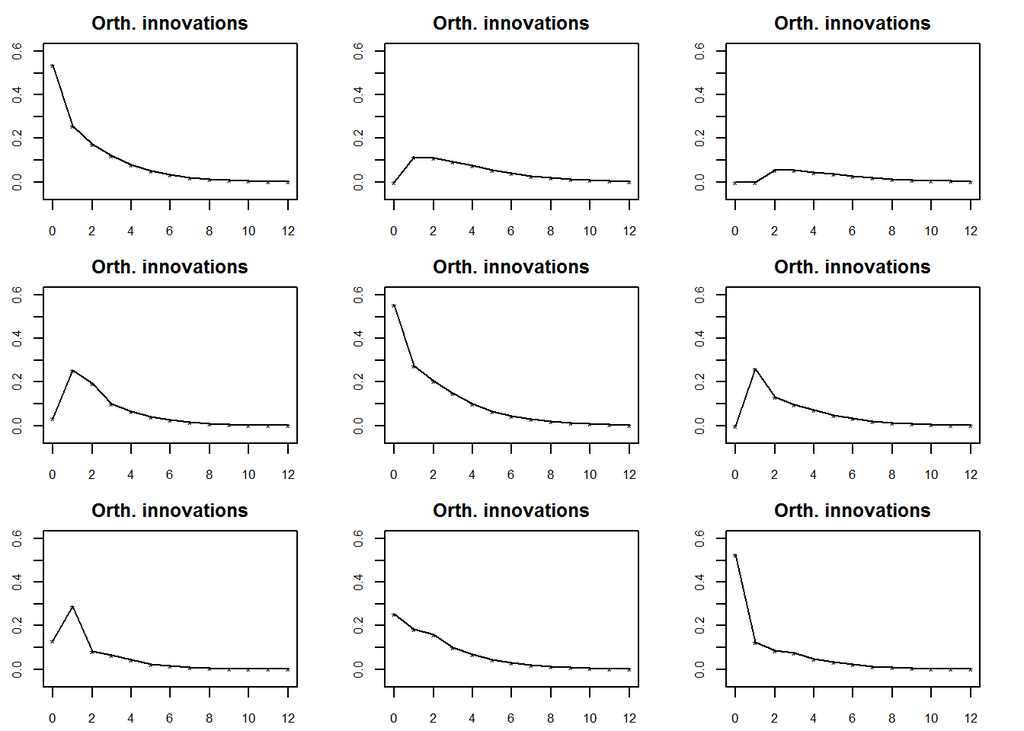

```
## Press return to continue
```

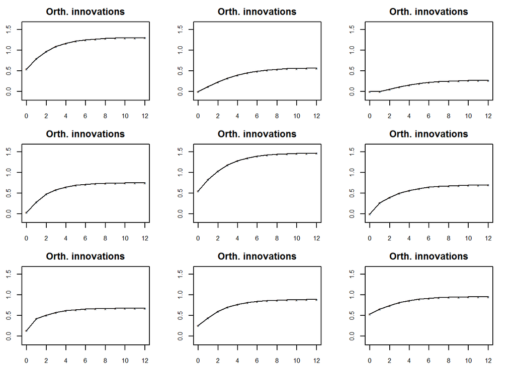

```r
### Funciones de impulso
Phi <- modelo.2$Phi
Sig <- modelo.2$Sigma
VARirf(Phi,Sig)
```

De los primeros gráficos, la función decae a cero rápidamente, esto se espera para las series estacionarias. Estos gráficos de funciones de impulso de respuesta muestran el efecto marginal, no los efectos condicionales. El gráfico superior derecho muestra un efecto de retrazo sobre UK cuando USA aumenta un paso o rezago.

La segunda gráfica muestra las funciones de impulso de respuesta acumulada para un modelo simplificado VAR(2), se espera que los efectos acumulados converjan al total de los multiplicadores rapidamente.

### **Descomposición de la varianza del error de predicción**

Se puede ver como la contribución a la varianza del $l-ésimo$ paso adelante del pronostico del error sobre la variable $Y_{kt}$. Siguiendo el ejemplo del PIB de UK, Canada y USA, tenemos en la siguiente tabla que la descomposición depende del orden de las componenetes de $\mathbf{Y_t}$, sin embargo los resultados muestran que las tres series estan interrelacionadas.

```r
### Descompisición de la varianza
Theta <- NULL
FEVdec(Phi,Theta,Sig,lag=5)
```

```
## Order of the ARMA mdoel:
## [1] 2 0
## Standard deviation of forecast error:
##           [,1]      [,2]      [,3]      [,4]      [,5]      [,6]
## [1,] 0.5385505 0.6082891 0.6444223 0.6644656 0.6745776 0.6796075
## [2,] 0.5550000 0.7197955 0.7839243 0.8100046 0.8217975 0.8268646
## [3,] 0.6022357 0.7040833 0.7317336 0.7453046 0.7510358 0.7534325
## Forecast-Error-Variance Decomposition
## Forecast horizon:  1
##             [,1]      [,2]      [,3]
## [1,] 1.000000000 0.0000000 0.0000000
## [2,] 0.003640595 0.9963594 0.0000000
## [3,] 0.047327504 0.1801224 0.7725501
## Forecast horizon:  2
##           [,1]      [,2]      [,3]
## [1,] 0.9645168 0.0354832 0.0000000
## [2,] 0.1266584 0.7400392 0.1333023
## [3,] 0.2044415 0.1999232 0.5956353
## Forecast horizon:  3
##           [,1]      [,2]        [,3]
## [1,] 0.9317343 0.0611510 0.007114686
## [2,] 0.1674484 0.6918164 0.140735255
## [3,] 0.2022145 0.2319992 0.565786354
## Forecast horizon:  4
##           [,1]       [,2]       [,3]
## [1,] 0.9094895 0.07752884 0.01298171
## [2,] 0.1722381 0.68151604 0.14624585
## [3,] 0.2027524 0.24163498 0.55561266
## Forecast horizon:  5
##           [,1]       [,2]       [,3]
## [1,] 0.8955543 0.08745053 0.01699521
## [2,] 0.1738199 0.67671058 0.14946952
## [3,] 0.2028420 0.24596465 0.55119338
## Forecast horizon:  6
##           [,1]       [,2]      [,3]
## [1,] 0.8877175 0.09280638 0.0194761
## [2,] 0.1741446 0.67493501 0.1509204
## [3,] 0.2026070 0.24789524 0.5494978
```

.  
.